```python
import matplotlib
import matplotlib.pyplot as plt
import numpy as np
```

**Ellipse and Gaussian Distribution**

Table of Contents

# 1. Coordinates

- basis $\{\hat e_1 \;\hat e_2 \}$ or basis $\{\hat q_1 \;\hat q_2 \}$

[figure not shown]

$$ \begin{align*} \overrightarrow{r}_I &= \begin{bmatrix}x_1\\x_2\end{bmatrix} \text{: coordinate of} \; \overrightarrow r \text{ in basis} \; \{\hat e_1 \;\hat e_2 \} \;(= I) \\ \overrightarrow{r}_Q &= \begin{bmatrix}y_1\\y_2\end{bmatrix} \text{: coordinate of} \;\overrightarrow r \text{ in basis} \;\{\hat q_1 \;\hat q_2 \} \;(= Q) \end{align*} $$

$$\begin{align*} \overrightarrow r & = x_1\hat{e}_1 + x_2\hat{e}_2 = y_1\hat{q}_1 + y_2\hat{q}_2 \\ & =\begin{bmatrix}\hat{e}_1&\hat{e}_2\end{bmatrix}\begin{bmatrix}x_1\\x_2\end{bmatrix}=\begin{bmatrix}\hat{q}_1&\hat{q}_2\end{bmatrix}\begin{bmatrix}y_1\\y_2\end{bmatrix} \\ \\ & \implies \begin{bmatrix}x_1\\x_2\end{bmatrix} = Q\begin{bmatrix}y_1\\y_2\end{bmatrix} \\ & \implies \begin{bmatrix}y_1\\y_2\end{bmatrix} = Q^{-1}\begin{bmatrix}x_1\\x_2\end{bmatrix}= Q^{T}\begin{bmatrix}x_1\\x_2\end{bmatrix} \end{align*}$$

- Coordinate change to basis of $\{\hat q_1 \hat q_2 \}$

$$ \underbrace{\begin{bmatrix}x_1\\x_2\end{bmatrix}}_{\text{coordinate in } I} \quad \underrightarrow{Q^T} \quad \underbrace{\begin{bmatrix}y_1\\y_2\end{bmatrix}}_{\text{coordinate in } Q} $$

# 2. Equation of an Ellipse

- unit circle

|  | $$ \begin{align*} & x_1^2 + x_2^2 = 1 \implies \\ \\ &\begin{bmatrix}x_1 & x_2 \end{bmatrix} \begin{bmatrix}1 & 0 \\ 0 & 1 \end{bmatrix} \begin{bmatrix}x_1 \\ x_2 \end{bmatrix} = 1 \end{align*}$$ |
| --- | --- |

- independent ellipse

[figure not shown]

$$ \begin{align*} &\frac{x_1^2}{a^2} + \frac{x_2^2}{b^2} = 1 \implies \begin{bmatrix}x_1 & x_2 \end{bmatrix} \begin{bmatrix}\frac{1}{a^2} & 0 \\ 0 & \frac{1}{b^2} \end{bmatrix} \begin{bmatrix}x_1 \\ x_2 \end{bmatrix} = 1 \\ & \implies \begin{bmatrix}x_1 & x_2 \end{bmatrix} \Sigma_x^{-1} \begin{bmatrix}x_1 \\ x_2 \end{bmatrix} = 1\\ \\ &\text{where} \; \Sigma_x^{-1} =\begin{bmatrix}\frac{1}{a^2} & 0\\ 0 & \frac{1}{b^2} \end{bmatrix}, \,\Sigma_x = \begin{bmatrix}a^2 & 0\\ 0 & b^2 \end{bmatrix} \end{align*}$$

- Rotated ellipse (dependent ellipse)
  - Coordinate changes

[figure not shown]

$$\begin{bmatrix}x_1 \\ x_2 \end{bmatrix} = u^T \begin{bmatrix}y_1 \\ y_2 \end{bmatrix},\quad \begin{array}{Icr} \begin{align} &x=u^Ty \\ &ux=y \end{align} \end{array} $$

- Now we know in basis $\{\hat x_1 \;\hat x_2 \} \;(= I)$

$$ x^T \Sigma_x^{-1}x = 1 \quad \text{and} \quad \Sigma_x = \begin{bmatrix}a^2 & 0\\ 0 & b^2 \end{bmatrix} $$

- Then, we can find $\Sigma_y$ such that

$$ y^T \Sigma_y^{-1}y = 1 \quad \text{and} \quad \Sigma_y = ? $$$$\implies x^T \Sigma_x^{-1} x = y^Tu\Sigma_x^{-1}u^Ty = 1 \quad (\Sigma_y^{-1} \; \text{: similar matrix to } \Sigma_x^{-1})$$

$$\begin{align*} \therefore \;\Sigma_y^{-1} &= u\Sigma_x^{-1}u^T \quad \text{or}\\ \Sigma_y &= u\Sigma_xu^T \end{align*}$$

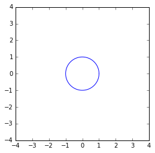

```python
theta = np.arange(0,2*np.pi,0.01)
x1 = np.cos(theta)
x2 = np.sin(theta)

%matplotlib inline
matplotlib.rcParams['figure.figsize'] = (4, 4)
plt.plot(x1, x2)

plt.xlim([-4., 4.])
plt.ylim([-4., 4.])
plt.show()
```

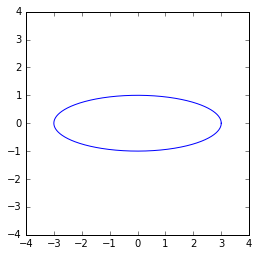

```python
%matplotlib inline
matplotlib.rcParams['figure.figsize'] = (4, 4)
theta = np.arange(0,2*np.pi,0.01)

x1 = 3*np.cos(theta);
x2 = np.sin(theta);

plt.plot(x1,x2)
plt.xlim([-4., 4.])
plt.ylim([-4., 4.])
plt.show()
```

$$ u = \left[\hat x_1 \;\hat x_2 \right] = \begin{bmatrix}\frac{1}{2} & -\frac{\sqrt{3}}{2}\\ \frac{\sqrt{3}}{2} & \frac{1}{2} \end{bmatrix}$$

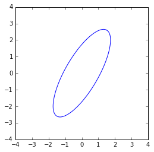

```python
%matplotlib inline
matplotlib.rcParams['figure.figsize'] = (4, 4)
theta = np.arange(0,2*np.pi,0.01)

u = np.array([[1./2., -np.sqrt(3)/2.], [np.sqrt(3)/2., 1./2.]])
X = np.array([x1, x2])
y = u.dot(X)

x1 = 3*np.cos(theta);
x2 = np.sin(theta);

plt.plot(y[0,:],y[1,:])
plt.xlim([-4., 4.])
plt.ylim([-4., 4.])
plt.show()
```

```python
Sx = np.array([[9, 0],[0, 1]])
Sy = u.dot(Sx).dot(u.transpose())
```

## 2.1. Question (reverse problem)

- Given $\Sigma_y^{-1}$ (or $\Sigma_y)$, how to find $a$ (major axis) and $b$ (minor axis) or **how to find the proper matrix $u$**
  - eigenvectors of $\Sigma$

$$A=S \Lambda S^T \qquad \text{where } S=[\upsilon_1 \; \upsilon_2] \text{ eigenvector of } A, \; \text{and }\Lambda=\begin{bmatrix} \lambda_1 & 0 \\ 0 & \lambda_2 \end{bmatrix}$$

$$ \text{here, }\, \Sigma_y = u\Sigma_xu^T = u \Lambda u^T \qquad \text{where } u = \begin{bmatrix}\hat{x}_1 & \hat{x}_2 \end{bmatrix} \text{ eigenvector of } \Sigma_y, \; \text{and }\Lambda=\begin{bmatrix} \lambda_1 & 0 \\ 0 & \lambda_2 \end{bmatrix} = \begin{bmatrix} a^2 & 0 \\ 0 & b^2 \end{bmatrix} $$

[figure not shown]

$$\begin{align*} \text{eigen-analysis} \begin{cases}\Sigma_y\hat{x}_1=\lambda_1 \hat{x}_1\\ \Sigma_y\hat{x}_2=\lambda_2 \hat{x}_2\\ \end{cases} \; \implies \; & \Sigma_y \underbrace{\begin{bmatrix}\hat{x}_1 & \hat{x}_2 \end{bmatrix}}_{u} = \underbrace{\begin{bmatrix} \hat{x}_1 & \hat{x}_2 \end{bmatrix}}_{u} \underbrace{\begin{bmatrix}\lambda_1 & 0 \\ 0 & \lambda_2 \end{bmatrix}}_{\Lambda} \\ \\ & \Sigma_y u = u\Lambda \\ & \Sigma_y = u \Lambda u^T = u \Sigma_x u^T \end{align*}$$

Therefore

$$\begin{array}{Icr} x=u^Ty \\ \begin{bmatrix}x_1 \\ x_2 \end{bmatrix} = u^T \begin{bmatrix} y_1 \\ y_2 \end{bmatrix} \end{array} \quad \quad \begin{array}{Icr} \begin{align*} & a=\sqrt{\lambda_1}\\ & b = \sqrt{\lambda_2}\\ & \text{major axis}=\hat{x}_1\\ & \text{minor axis}=\hat{x}_2 \end{align*} \end{array}$$

```python
Sy = np.array([[3.0000 ,   3.4641],
    [3.4641,    7.0000]])
[D, U] = np.linalg.eig(Sy)
# sorting
sort_indices = np.argsort(D)[::-1]
D[:] = D[sort_indices]
U = U[:,sort_indices]
```

## 2.2. Summary

[figure not shown]

$$ \begin{align*} x &=u^Ty \\ u &=\begin{bmatrix}\hat{x}_1 & \hat{x}_2\end{bmatrix} \end{align*}$$

- independent ellipse in $\{\hat{x}_1, \hat{x}_2 \}$
- dependent ellipse in $\{ \hat{y}_1, \hat{y}_2 \}$
- Decouple
  - diagonalize
  - eigen-analysis

# 3. Gaussian Distribution

## 3.1. Standard univariate normal distribution $\sim N(0,1^2)$

| $$ P_Y\left(Y=y\right)=\frac{1}{\sqrt{2\pi}}\exp\left(-\frac{1}{2}y^2\right)$$ $$ \frac{1}{2} y^2 = \text{const} \implies \text{prob. contour}$$ |  |
| --- | --- |

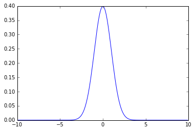

```python
%matplotlib inline
y = np.arange(-10,10,0.1)
ProbG = 1./np.sqrt(2*np.pi)*np.exp(-1./2.*y**2)
plt.plot(y, ProbG)
```

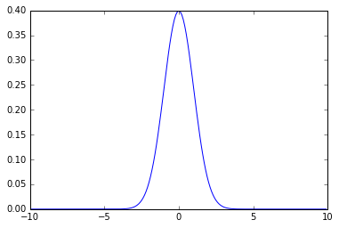

```python
def normpdf_python(x, mu, sigma):
    return 1/(sigma*np.sqrt(2*np.pi))*np.exp(-1*(x-mu)**2/2*sigma**2)

ProbG2 = normpdf_python(y, 0, 1)
plt.plot(y, ProbG2)
```

```
<function matplotlib.pyplot.show>
```

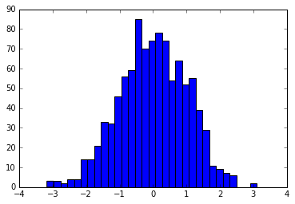

```python
x = np.random.randn( 1000, 1)
plt.hist(x, 31)
plt.show
```

## 3.2. Univariate Normal distribution $\sim N\left(\mu,\sigma^2\right)$

- Gaussian or normal distribution, 1D (mean $\mu$, variance $\sigma^2$)

$$ N(x;\mu,\sigma) = \frac{1}{\sqrt{2\pi\sigma^2}}\exp\left(-\frac{1}{2}\frac{\left(x-\mu\right)^2}{\sigma^2}\right) $$

[output not shown]

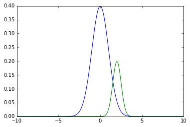

```python
mu = 2
sigma = 2

x = np.arange(-10, 10, 0.1)
ProbG3 = 1/(sigma*np.sqrt(2*np.pi))*np.exp(-1*(x-mu)**2/2*sigma**2)
plt.plot(y,ProbG,x,ProbG3)
```

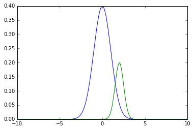

```python
mu = 2
sigma = 2

x = np.arange(-10, 10, 0.1)
def normpdf_python(x, mu, sigma):
    return 1/(sigma*np.sqrt(2*np.pi))*np.exp(-1*(x-mu)**2/2*sigma**2)

ProbG4 = normpdf_python(x,mu,sigma);
plt.plot(y,ProbG,x,ProbG4)
```

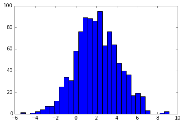

```python
x = mu + sigma*np.random.randn(1000,1)
plt.hist(x, 31)
plt.show()
```

## 3.3. Multivariate Gaussian models

- Similar to a univariate case, but in a matrix form

$$ \begin{align*} N\big(x; \mu,\Sigma\big) &= \frac{1}{(2\pi)^{\frac{n}{2}}\big\vert\Sigma\big\vert^{\frac{1}{2}}}\exp\left(-\frac{1}{2}\left(x-\mu\right)^T\Sigma^{-1}\left(x-\mu\right)\right) \\ \\ \mu &= \text{length}\,\, n \,\,\text{column vector} \\ \Sigma &= n \times n \,\,\text{matrix (covariance matrix)} \\ \lvert\Sigma\rvert &= \text{matrix determinant}\end{align*}$$

- Multivariate Gaussian models and ellipse
  - Ellipse shows constant $\Delta^2$ value... $$ \Delta^2 = (x-\mu)^T\Sigma^{-1} (x-\mu)$$

### 3.3.1. Two *independent* variables

$$ \begin{align*} P\left(X_1=x_1,X_2=x_2\right) &= P_{X_1}\left(x_1\right)P_{X_2}\left(x_2\right) \\ &\sim \exp \left(-\frac{1}{2} \frac{\left(x_1-\mu_{x_1}\right)^2}{\sigma_{x_1}^2}\right) \cdot \exp \left(-\frac{1}{2} \frac{\left(x_2-\mu_{x_2}\right)^2}{\sigma_{x_2}^2}\right) \\ &\sim\exp \left(-\frac{1}{2}\left(\frac{x_1^2}{\sigma_{x_1}^2} + \frac{x_2^2}{\sigma_{x_2}^2}\right)\right)\\ \end{align*} $$

- in a matrix form

$$ P(x_1) \cdot P(x_2)=\frac{1}{Z_1Z_2}\exp\left(-\frac{1}{2}(x-\mu)^T\Sigma^{-1}(x-\mu)\right) $$$$\left ( x=\begin{bmatrix} x_1 \\ x_2 \end{bmatrix}, \quad \mu = \begin{bmatrix} \mu_1 \\ \mu_2 \end{bmatrix}, \quad \Sigma = \begin{bmatrix}\sigma_{x_1}^2 & 0 \\ 0 & \sigma_{x_2}^2 \end{bmatrix} \right )$$

[output not shown]

- Summary in a matrix form

$$ \begin{align*}N\left(0,\Sigma_x\right) &\sim \exp\left(-\frac{1}{2}x^T \Sigma_x^{-1} x\right) \\ N\left(\mu_x,\Sigma_x\right) &\sim \exp\left(-\frac{1}{2}\left(x-\mu_x\right)^T \Sigma_x^{-1} \left(x-\mu_x\right)\right) \end{align*}$$

```
(-6.0, 6.0)
```

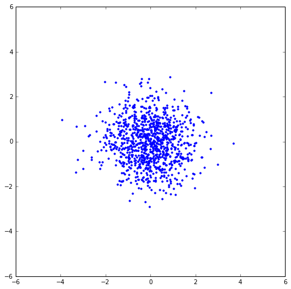

```python
%matplotlib inline
matplotlib.rcParams['figure.figsize'] = (8, 8)
mu = np.array([0, 0])
sigma = np.eye(2)
m = 1000

x = np.random.multivariate_normal(mu, sigma, m)
plt.plot(x[:, 0], x[:, 1], '.')

plt.xlim([-6., 6.])
plt.ylim([-6., 6.])
```

```
(-6.0, 6.0)
```

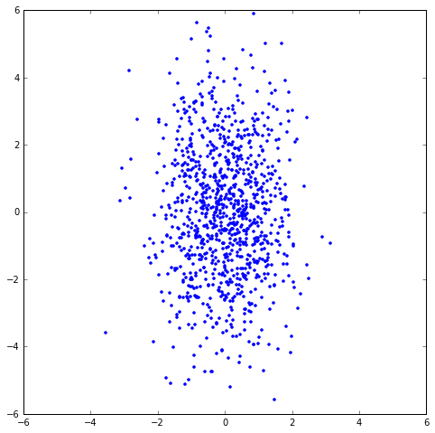

```python
%matplotlib inline
matplotlib.rcParams['figure.figsize'] = (8, 8)
mu = np.array([0, 0])
sigma = np.array([[1, 0], [0, 4]])
m = 1000

x = np.random.multivariate_normal(mu, sigma, m)
plt.plot(x[:, 0], x[:, 1], '.')
plt.ylim([-6., 6.])
plt.xlim([-6., 6.])
```

### 3.3.1. Two *dependent* variables in $\{y_1,y_2\}$

[figure not shown]

- Compute $P_Y(y)$ from $P_X(x)$ $$\begin{align*} P_X(x) = P_Y(y) \;\ \text{where}\;\; & x = \begin{bmatrix}x_1 \\ x_2\end{bmatrix}, y = \begin{bmatrix}y_1 \\ y_2 \end{bmatrix} \end{align*}$$
- Relationship between $y$ and $x$

$$ x = \begin{bmatrix}\hat{x}_1 & \hat{x}_2 \end{bmatrix}^T y = u^Ty $$

$$x^T\Sigma_x^{-1} x = y^Tu\Sigma_x^{-1}u^Ty = y^T \Sigma_y^{-1} y\\ \therefore \;\; \Sigma_y^{-1} = u\Sigma_x^{-1} u^T$$

$$\rightarrow \Sigma_y = u\Sigma_x u^T$$

- $\Sigma_x$ : covariance matrix of $x$
- $\Sigma_y$ : covariance matrix of $y$
- If $u$ is an eigenvector matrix of $\Sigma_y$, then $\Sigma_x$ is a diagonal matrix

```
(-6.0, 6.0)
```

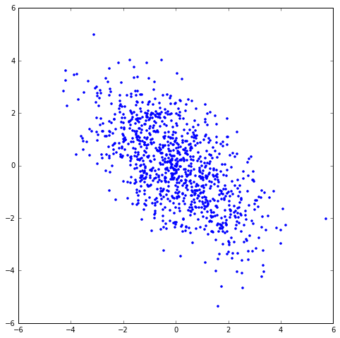

```python
%matplotlib inline
matplotlib.rcParams['figure.figsize'] = (8, 8)
mu = np.array([0, 0])
sigma = 1./2.*np.array([[5, -3], [-3, 5]])
m = 1000

x = np.random.multivariate_normal(mu, sigma, m)
plt.plot(x[:, 0], x[:, 1], '.')
plt.ylim([-6., 6.])
plt.xlim([-6., 6.])
```

**Remark**

$$ \begin{align*} & x \sim N(\mu_x,\Sigma_x) \text{ and } y = Ax + b \; \text{affine transformation}\\ \\ \implies \; & y \sim N(\mu_y,\Sigma_y) = N(A\mu_x+b,A\Sigma_xA^T)\\ \implies \; & y \;\; \text{is also Gaussian with} \;\; \mu_y = Ax+b, \;\; \Sigma_y = A \Sigma_x A^T \end{align*}$$

## 3.4. Decouple using covariance matrix

Given data, how to find $\Sigma_y$ and major(or minor) axis (assume $\mu_y = 0$)

$$ \Sigma_y = \begin{bmatrix} \text{var}(y_1) & \text{cov}(y_1,y_2)\\ \text{cov}(y_2,y_1) & \text{var}(y_2) \end{bmatrix}$$

[figure not shown]

$$\begin{array}{Icr} \text{eigen-analysis} \\ \\ \Sigma_y\hat{x}_1 = \lambda_1\hat{x}_1 \\ \Sigma_y\hat{x}_2 = \lambda_2\hat{x}_2 \end{array} \quad \quad \begin{array}{Icr} \Sigma_x^{-1} = \begin{bmatrix} \frac{1}{\sqrt{\lambda_1}^2} & 0 \\ 0 & \frac{1}{\sqrt{\lambda_2}^2} \end{bmatrix} \\ \Sigma_x = \begin{bmatrix}\sqrt{\lambda_1}^2 & 0 \\ 0 & \sqrt{\lambda_2}^2 \end{bmatrix} \end{array} $$

$$\begin{array}{Icr} \begin{align*} \Sigma_y \begin{bmatrix} \hat{x}_1 & \hat{x}_2 \end{bmatrix} &= \begin{bmatrix} \hat{x}_1 & \hat{x}_2 \end{bmatrix} \begin{bmatrix} \lambda_1 & 0 \\ 0 & \lambda_2 \end{bmatrix}\\ &= \begin{bmatrix}\hat{x}_1 & \hat{x}_2 \end{bmatrix} \Sigma_{x} \\ \\ \Sigma_y &= u \Sigma_x u^T \end{align*} \end{array} \quad \quad \quad \begin{array}{Icr} y = ux \implies u^Ty = x \\ \begin{bmatrix} \hat{x}_1 & \hat{x}_2 \end{bmatrix} = u \\ \\ \\ \end{array}$$

```python
S = np.cov(x.transpose())
print ("S = \n", S)
[D, V] = np.linalg.eig(S)
print ("V = \n", V)
print ("D = \n", D)
```

```
S =
 [[ 2.44008465 -1.49829633]
 [-1.49829633  2.48508924]]
V =
 [[-0.71239627  0.70177742]
 [-0.70177742 -0.71239627]]
D =
 [ 0.96412165  3.96105224]
```

# 4. Geometry of the Gaussian

$$ \Delta^2 = (x-\mu)^T\Sigma^{-1} (x-\mu) \quad \text{Ellipse shows constant $\Delta^2$ value...}$$

- Write in terms of eigenvectors

$$ \begin{align*} \Sigma &= U\Lambda U^T \\ \Sigma &= \begin{bmatrix}u_1 & u_2 \\ \downarrow & \downarrow \end{bmatrix} \begin{bmatrix}\lambda_1 & 0 \\ 0 & \lambda_2\end{bmatrix} \begin{bmatrix}u_1 & \rightarrow \\ u_2 & \rightarrow \end{bmatrix} \end{align*}$$

- Then

$$y_i = u_i^T(x-\mu) $$$$\Delta^2 = \frac{y_1^2}{\lambda_1}+\frac{y_2^2}{\lambda_2} $$

[figure not shown]

## 4.1. Numerical Demo

```
(-6.0, 6.0)
```

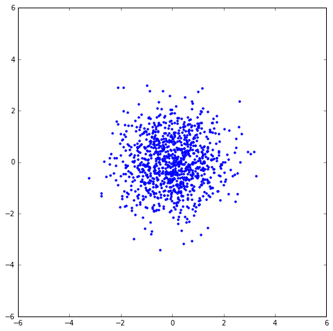

```python
%matplotlib inline
matplotlib.rcParams['figure.figsize'] = (8, 8)
mu = np.array([0, 0])
sigma = np.eye(2)
m = 1000

x = np.random.multivariate_normal(mu, sigma, m)
plt.plot(x[:, 0], x[:, 1], '.')
plt.ylim([-6., 6.])
plt.xlim([-6., 6.])
```

**Scaling**

$$ x_B = \Lambda^{\frac{1}{2}} x_A = \begin{bmatrix}3 & 0 \\ 0 & 1\end{bmatrix} \cdot x_A$$

```
(-10.0, 10.0)
```

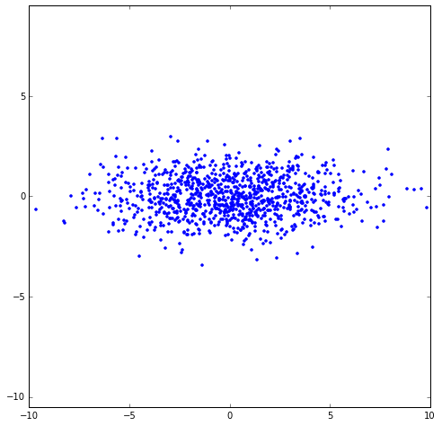

```python
%matplotlib inline
matplotlib.rcParams['figure.figsize'] = (8, 8)
A = np.array([[3, 0], [0, 1]]);
y = A.dot(x.transpose());
plt.plot(y[0,:],y[1,:],'.')
plt.axis('equal')
plt.xlim([-10., 10.])
```

**Rotating**

$$x_C = U^T\Lambda^{\frac{1}{2}} x_A = \begin{bmatrix}\cos\theta & -\sin\theta \\ \sin\theta & \cos\theta \end{bmatrix} \cdot x_B$$

```
(-10.0, 10.0)
```

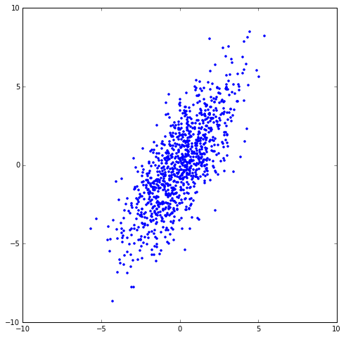

```python
%matplotlib inline
matplotlib.rcParams['figure.figsize'] = (8, 8)

theta = np.pi/3

R = np.array([[np.cos(theta), -np.sin(theta)],
     [np.sin(theta), np.cos(theta)]])

z = R.dot(y);

plt.plot(z[0,:],z[1,:],'.')
plt.axis('equal')
plt.xlim([-10., 10.])
```

**Shifting**

$$ x_D = x_C + \mu = x_C + \begin{bmatrix} \mu_x \\ \mu_y\end{bmatrix}$$

```
(-10.0, 10.0)
```

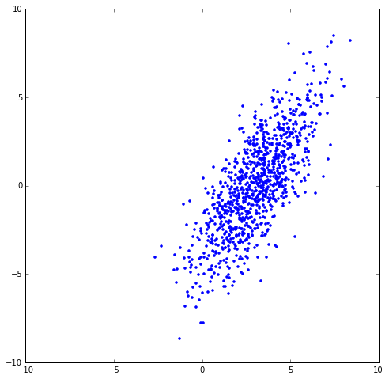

```python
%matplotlib inline
matplotlib.rcParams['figure.figsize'] = (8, 8)

theta = np.pi/3

R = np.array([[np.cos(theta), -np.sin(theta)],
     [np.sin(theta), np.cos(theta)]])

z = R.dot(y);
mu = np.array([[3], [0]]);
w = z + np.repeat(mu,z.shape[1], axis = 1);


plt.plot(w[0,:],w[1,:],'.')
plt.axis('equal')
plt.xlim([-10., 10.])
```

**Recovery**

```python
m = w.shape[1];
mu_hat = np.array([np.mean(w, 1)]).transpose()
mu_hat
```

```
array([[ 3.04881773],
       [ 0.02955069]])
```

```python
z = w - np.repeat(mu_hat,m, axis = 1)
S = 1./m*z.dot(z.transpose())
S
```

```
array([[ 3.09954715,  3.61900895],
       [ 3.61900895,  7.48296936]])
```

```python
[D, U] = np.linalg.eig(S)
# sorting
sort_indices = np.argsort(D)[::-1]
D[:] = D[sort_indices]
U = U[:,sort_indices]
print (D)
print (U)
```

```
[ 9.52219472  1.06032178]
[[-0.49090715 -0.87121189]
 [-0.87121189  0.49090715]]
```

```
(-10.0, 10.0)
```

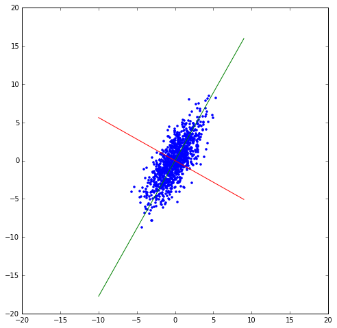

```python
%matplotlib inline
matplotlib.rcParams['figure.figsize'] = (8, 8)

xp = np.arange(-10., 10., 1)


plt.plot(z[0,:],z[1,:],'.')
plt.plot(xp, U[1,0]/U[0,0]*xp)
plt.plot(xp, U[1,1]/U[0,1]*xp)
plt.axis('equal')
plt.xlim([-10., 10.])
```

```
(-10.0, 10.0)
```

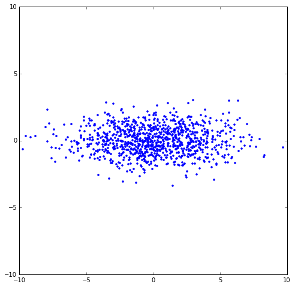

```python
%matplotlib inline
matplotlib.rcParams['figure.figsize'] = (8, 8)

y = U.transpose().dot(z);


plt.plot(y[0,:],y[1,:],'.')
plt.axis('equal')
plt.xlim([-10., 10.])
```

```python
L = 1./m*y.dot(y.transpose());
[D, U] = np.linalg.eig(L);
D
```

```
array([ 9.52219472,  1.06032178])
```

```python
sort_indices = np.argsort(D)[::-1]
D[:] = D[sort_indices]
U = U[:,sort_indices]
```

```
(-10.0, 10.0)
```

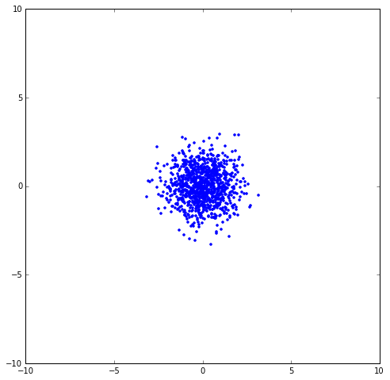

```python
%matplotlib inline
matplotlib.rcParams['figure.figsize'] = (8, 8)
DM = np.diag(D)
F = np.sqrt(DM)
x = np.linalg.inv(F).dot(y)
plt.plot(x[0,:],x[1,:],'.')
plt.ylim([-10., 10.])
plt.xlim([-10., 10.])
```

```python
%%javascript
$.getScript('https://kmahelona.github.io/ipython_notebook_goodies/ipython_notebook_toc.js')
```